# Simple example of how to use NSEpy with backtrader

## Introduction

This is a simple example to show how you can use [P/E ratio](http://www.investopedia.com/terms/p/price-earningsratio.asp) to make investment decision. Our investment of choice is NIFTY index for simplicity (Though you cannot invest directly in the NIFTY, you can invest in any one of [11 Exchange traded funds which are based on NIFTY](https://www.nseindia.com/products/content/equities/etfs/equity.htm))

Lets get into tools and strategies now. To downloading index historical data we are going to use [**NSEpy**](http://nsepy.readthedocs.io/en/latest/). For back-testing our strategy we are using [**backtrader**](https://www.backtrader.com/). Install dependencies - `pip install nsepy backtrader`

### Downloading the data

Download the data from NSE takes a significan time and you do not want to wait everytime you tweak your strategies. Therefore we download the data and save it to disk.

```python
#%matplotlib inline
from datetime import date
import pandas as pd
try:
    nifty = pd.read_csv('data/nifty17years_withPE.csv')
    print('Read from disk successful')
except:
    print('Downloading from NSE')
    nifty = get_history('NIFTY', date(2000, 1, 1), date(2017, 10, 31), index=True)
    pe = get_index_pe_history('NIFTY', date(2000, 1, 1), date(2017, 10, 31))
    nifty['PE'] = pe['P/E']
    nifty.to_csv('data/nifty17years_withPE.csv')
```

[output not shown]

### Load the data in backtrader and run the strategy

```python
from backtrader.feeds import GenericCSVData

"""
    By default downloaded data only has datetime, Open, High, Low, Close, Volume and Turnover.
    As we are adding one more parameter "PE", we can no longer use GenericCSVData reader provided by
    backtrader library without modification to base class.
"""
# Define the new parameter
class GenericCSV_PE(GenericCSVData):
    # Add a 'pe' line to the inherited ones from the base class
    lines = ('pe',)

    # add the parameter to the parameters inherited from the base class
    params = (('pe', 8),)


# Declare position of each column in csv file
data = GenericCSV_PE(dataname='data/nifty17years_withPE.csv',
                     dtformat=('%Y-%m-%d'),
                     datetime=0,
                     high=1,
                     low=2,
                     open=3,
                     close=4,
                     volume=5,
                     pe=7,
                     openinterest=-1,
                     #fromdate=date(2017,1,1),
                     #todate=date(2017,1,10)
                    )
```

## Defining the strategy

Defining the strategy described in introduction.

```python
import backtrader as bt


class PEInvesting(bt.SignalStrategy):
    def log(self, txt, dt=None):
        pass

    def __init__(self):
        # Keep a reference to the "close" line in the data[0] dataseries
        self.dataclose = self.datas[0].close
        self.pe = self.datas[0].pe


    def next(self):
        curdate = self.datetime.date(ago=0)

        if self.pe[0] < 21:
            self.log(self.dataclose[0])
            # Use 100% of the cash to buy nifty
            self.order_target_percent(target=1.0)


        if self.pe[0] > 24:
            self.log(self.dataclose[0])
            # Sell everything
            self.order_target_percent(target=0)
```

### Running the defined strategy

Run the strategy, Get final portfolio value and plot the whole backtesting.

```
Final Portfolio Value: 10450659.40
Final value is 10.45 times the initial investment
```

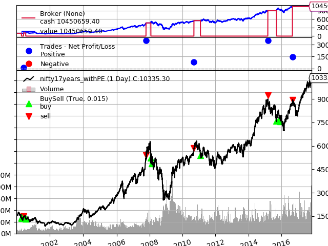

```python
cerebro = bt.Cerebro()

# Set our desired cash start
cerebro.broker.setcash(1000000.0)
cerebro.adddata(data)

cerebro.addstrategy(PEInvesting)
cerebro.run()
print('Final Portfolio Value: %.2f' % cerebro.broker.getvalue())
print('Final value is %.2f times the initial investment'%(cerebro.broker.getvalue()/1000000.0))
cerebro.plot()
```

### Next steps

Play with different possible strategies, eg.

- Try different values of PE for buying and selling
- Try a formula to map relation between P/E value and percentage allocation

In next notebook I'll try to backtest for systematic investing (SIP) where we will invest every month and try different strategies for SIP.